```python
import tensorflow as tf
import numpy as np
import pandas as pd
import tensorflow.keras.preprocessing.image as image_util
import matplotlib.pyplot as plt
from tensorflow.keras.models import Sequential
from tensorflow.keras.layers import Dense, Activation, Flatten, MaxPooling2D, BatchNormalization, Conv2D, Dropout
%matplotlib inline
```

# [帰納法]'0'と'1'の手書き文字を判断

- 学習データ: '0'と'1'の画像データそれぞれ1,000枚
- 多層ニューラルネットワークは画像の特徴量を抽出し、手書き文字を分類するネットワーク
- 入力データ: 画像データ、回答データ: '0' or '1'

# データ読み込み

- 1と0の画像をそれぞれ1000枚ずつ読み込みます

```python
def load_data():
    label_zero_images = pd.read_csv("./data/0.csv") # => 1000行のCSV
    label_one_images = pd.read_csv("./data/1.csv") # => 1000行のCSV
    label_zero = label_zero_images["label"].values
    image_zero = label_zero_images.drop("label", axis=1)
    label_one = label_one_images["label"].values
    image_one = label_one_images.drop("label", axis=1)
    reshape_zero_images = image_zero.values.reshape(len(image_zero), 28, 28, 1)
    reshape_one_images = image_one.values.reshape(len(image_one), 28 , 28, 1)
    return label_zero, reshape_zero_images, label_one, reshape_one_images

def load_train_data():
    label_zero_images = pd.read_csv("./data/0.csv") # => 1000行のCSV
    label_one_images = pd.read_csv("./data/1.csv") # => 1000行のCSV
    concat_images = pd.concat([label_zero_images[0:995], label_one_images[0:995]])
    test_zero_images = label_zero_images[995:1000].drop("label", axis=1).values.reshape(5, 28, 28, 1)
    test_one_images = label_one_images[995:1000].drop("label", axis=1).values.reshape(5, 28, 28, 1)

    return concat_images.sample(frac=1).reset_index(drop=True), test_zero_images, test_one_images
```

```python
label_zero, image_zero, label_one, image_one = load_data()
concat_images, test_zero_images, test_one_images = load_train_data()
concat_images.describe()
```

|  | label | pixel0 | pixel1 | pixel2 | pixel3 | pixel4 | pixel5 | pixel6 | pixel7 | pixel8 | ... | pixel774 | pixel775 | pixel776 | pixel777 | pixel778 | pixel779 | pixel780 | pixel781 | pixel782 | pixel783 |
| --- | --- | --- | --- | --- | --- | --- | --- | --- | --- | --- | --- | --- | --- | --- | --- | --- | --- | --- | --- | --- | --- |
| count | 1990.000000 | 1990.0 | 1990.0 | 1990.0 | 1990.0 | 1990.0 | 1990.0 | 1990.0 | 1990.0 | 1990.0 | ... | 1990.0 | 1990.0 | 1990.0 | 1990.0 | 1990.0 | 1990.0 | 1990.0 | 1990.0 | 1990.0 | 1990.0 |
| mean | 0.500000 | 0.0 | 0.0 | 0.0 | 0.0 | 0.0 | 0.0 | 0.0 | 0.0 | 0.0 | ... | 0.0 | 0.0 | 0.0 | 0.0 | 0.0 | 0.0 | 0.0 | 0.0 | 0.0 | 0.0 |
| std | 0.500126 | 0.0 | 0.0 | 0.0 | 0.0 | 0.0 | 0.0 | 0.0 | 0.0 | 0.0 | ... | 0.0 | 0.0 | 0.0 | 0.0 | 0.0 | 0.0 | 0.0 | 0.0 | 0.0 | 0.0 |
| min | 0.000000 | 0.0 | 0.0 | 0.0 | 0.0 | 0.0 | 0.0 | 0.0 | 0.0 | 0.0 | ... | 0.0 | 0.0 | 0.0 | 0.0 | 0.0 | 0.0 | 0.0 | 0.0 | 0.0 | 0.0 |
| 25% | 0.000000 | 0.0 | 0.0 | 0.0 | 0.0 | 0.0 | 0.0 | 0.0 | 0.0 | 0.0 | ... | 0.0 | 0.0 | 0.0 | 0.0 | 0.0 | 0.0 | 0.0 | 0.0 | 0.0 | 0.0 |
| 50% | 0.500000 | 0.0 | 0.0 | 0.0 | 0.0 | 0.0 | 0.0 | 0.0 | 0.0 | 0.0 | ... | 0.0 | 0.0 | 0.0 | 0.0 | 0.0 | 0.0 | 0.0 | 0.0 | 0.0 | 0.0 |
| 75% | 1.000000 | 0.0 | 0.0 | 0.0 | 0.0 | 0.0 | 0.0 | 0.0 | 0.0 | 0.0 | ... | 0.0 | 0.0 | 0.0 | 0.0 | 0.0 | 0.0 | 0.0 | 0.0 | 0.0 | 0.0 |
| max | 1.000000 | 0.0 | 0.0 | 0.0 | 0.0 | 0.0 | 0.0 | 0.0 | 0.0 | 0.0 | ... | 0.0 | 0.0 | 0.0 | 0.0 | 0.0 | 0.0 | 0.0 | 0.0 | 0.0 | 0.0 |

8 rows × 785 columns

# データを5枚ずつ読み込んで確認します

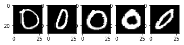

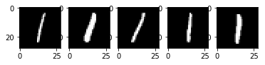

```python
def show_data(image_data, count=5):
    for i in range(count):
        image = image_data[i]
        plt.subplot(1,5,i+1)
        plt.imshow(image_util.array_to_img(image))
    plt.show()

show_data(image_zero)
show_data(image_one)
```

# 学習ネットワークを定義

```python
model = Sequential()
model.add(Conv2D(32, kernel_size=(3, 3), activation='relu', input_shape=(28, 28, 1)))
model.add(Conv2D(64, (3, 3), activation='relu'))
model.add(MaxPooling2D(pool_size=(2, 2)))
model.add(Dropout(0.25))
model.add(Flatten())
model.add(Dense(128, activation='relu'))
model.add(Dropout(0.5))
model.add(Dense(2, activation='softmax'))
model.summary()
```

```
_________________________________________________________________
Layer (type)                 Output Shape              Param #
=================================================================
conv2d_18 (Conv2D)           (None, 26, 26, 32)        320
_________________________________________________________________
conv2d_19 (Conv2D)           (None, 24, 24, 64)        18496
_________________________________________________________________
max_pooling2d_10 (MaxPooling (None, 12, 12, 64)        0
_________________________________________________________________
dropout_12 (Dropout)         (None, 12, 12, 64)        0
_________________________________________________________________
flatten_6 (Flatten)          (None, 9216)              0
_________________________________________________________________
dense_12 (Dense)             (None, 128)               1179776
_________________________________________________________________
dropout_13 (Dropout)         (None, 128)               0
_________________________________________________________________
dense_13 (Dense)             (None, 2)                 258
=================================================================
Total params: 1,198,850
Trainable params: 1,198,850
Non-trainable params: 0
_________________________________________________________________
```

```python
train_y = tf.keras.utils.to_categorical(concat_images["label"].values, 2)
train_x = concat_images.drop("label", axis=1).values.reshape(len(concat_images), 28, 28, 1)
```

# 学習を実施

```python
from tensorflow.keras.optimizers import RMSprop

model.compile(loss='categorical_crossentropy',
              optimizer=RMSprop(),
              metrics=['accuracy'])

history = model.fit(train_x, train_y,
                    batch_size=100,
                    epochs=10,
                    verbose=1,
                   shuffle=True,
                   validation_split=0.1)
```

```
Train on 1791 samples, validate on 199 samples
```

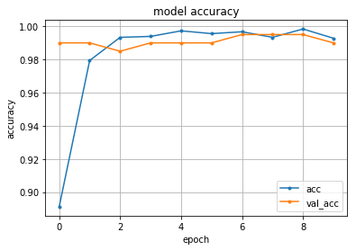

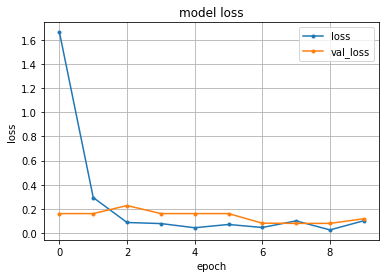

```python
def plot_history(history):
    plt.plot(history.history['acc'], marker='.', label='acc')
    plt.plot(history.history['val_acc'], marker='.', label='val_acc')
    plt.title('model accuracy')
    plt.grid()
    plt.xlabel('epoch')
    plt.ylabel('accuracy')
    plt.legend(loc='best')
    plt.show()

    plt.plot(history.history['loss'], marker='.', label='loss')
    plt.plot(history.history['val_loss'], marker='.', label='val_loss')
    plt.title('model loss')
    plt.grid()
    plt.xlabel('epoch')
    plt.ylabel('loss')
    plt.legend(loc='best')
    plt.show()
# 学習履歴をプロット
plot_history(history)
```

```python
# AIがよくブラックボックスと思われがちなのがこの数字の部分
model.get_layer('conv2d_18').get_weights()
```

[output not shown]

[output cut: 35 more lines]

[output not shown]

# 学習したモデルで推論する

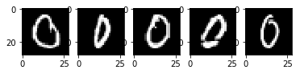

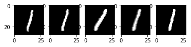

```python
show_data(test_zero_images)
show_data(test_one_images)
```

```python
model.predict(test_zero_images)
```

```
array([[1., 0.],
       [1., 0.],
       [1., 0.],
       [1., 0.],
       [1., 0.]], dtype=float32)
```

```python
model.predict(test_one_images)
```

```
array([[0., 1.],
       [0., 1.],
       [0., 1.],
       [0., 1.],
       [0., 1.]], dtype=float32)
```

# [演繹法]'0'か'1'の手書き文字を判断する

- '1'と'0'の違いを判断するのは人間は形で判断している
- 0と判断しているときは「0の形をしているもの」をみている
- 0の画像に「近い」ほうを0とする、それ以外を1と判断する
- 「近い」を表現するために'0'と'1'それぞれ995枚の画像データを用意しておき、その中から最も近いものを選択すると'0'か'1'か判断できます

# このルールの問題点

- 995枚のデータのいずれかに似ているということが条件になります
- 例えば手書き文字の位置がずれていたり、画像の光度が違って違う色に見えたりすることで途端に精度が落ちます

```python
# k近傍方の実装
class NearestNeighbor(object):
  # 「近い」を表現するための画像を用意する
  def train(self, X, y):
    self.Xtr = X
    self.ytr = y

  # 入力画像が学習画像のどれに最も近いのか表現する
  def predict(self, X):
    num_test = X.shape[0]
    Ypred = np.zeros(num_test, dtype = self.ytr.dtype)

    # 入力画像に対してそれぞれ最も近い画像を探す
    for i in range(num_test):
      # 各画像の誤差の絶対値を加算することで画像との差分を計算する
      distances = np.sum(np.abs(self.Xtr - X[i,:]), axis = 1)
      # 最も距離が小さいものを選択する
      min_index = np.argmin(distances)
      # それに対応する答えをセットする
      Ypred[i] = self.ytr[min_index]

    return Ypred
```

```python
nearest_neighbor = NearestNeighbor()
concat_images, test_zero_images, test_one_images = load_train_data()
concat_images.describe()
y = concat_images["label"]
X = concat_images.drop("label", axis=1)
test_flatten_zero_images = test_zero_images.reshape(len(test_zero_images), 784)
test_flatten_one_images = test_one_images.reshape(len(test_one_images), 784)
nearest_neighbor.train(X, y)
```

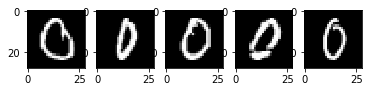

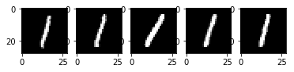

```python
show_data(test_zero_images)
show_data(test_one_images)
```

```python
nearest_neighbor.predict(test_flatten_zero_images)
```

```
array([0, 0, 0, 0, 0])
```

```python
nearest_neighbor.predict(test_flatten_one_images)
```

```
array([1, 1, 1, 1, 1])
```